# Bayesian Project Report

Maggie Ha - Thomas Duong

2025-04-01

#### Abstract

This project models the proportion of health insurance coverage in Texas counties. We develop Bayesian regression models that use global-local priors and apply them to two datasets including average income of Texas counties. We also explored associations between the percentage of uninsured and average income. We compared the results between models and between two datasets that are 10 years apart. The posterior simulations are carried out in JAGS.

#### 1. Introduction

Access to health insurance is a crucial determinant of overall well-being, yet coverage rates vary significantly across different regions. Understanding the factors influencing health insurance coverage is essential for informing policy decisions. This study focuses on modeling the proportion of uninsured individuals across Texas counties, with a particular emphasis on the relationship between insurance coverage and economic factors such as average income.

In this project, we employed Bayesian regression models incorporating global-local priors, allowing for robust estimation and improved handling of complex data structures. We analyze two datasets collected from Small Area Health Insurance Estimates Programs (SAHIE) in 2012 and 2022, enabling a comparative assessment of changes in uninsured rates over time. By leveraging posterior simulations implemented in JAGS, we evaluate model performance between income levels and insurance coverage.

#### 2. Methods

Employ Bayesian regression models with global-local priors to model the proportion of health insurance coverage across counties in Texas using two datasets from Small Area Health Insurance Estimates Programs (SAHIE) in 2012 and 2022. Specifically, the models were used to assess the relationship between the percentage of uninsured individuals and average income in Texas counties.

Leverage Markov Chain Monte Carlo (MCMC) techniques to sample from posterior distributions and generate credible intervals for parameters.

Compare the results with the standard model without global-local priors.

#### 3. Models

Model without Global-Local Priors
$$\begin{equation}
y_i|\beta_0, \beta_1 \sim \mathcal{N}(\beta_0 + \beta_1 x_i,
\tau_i) , \quad i= 1, \cdots ,254
\end{equation}$$
$$\begin{equation}
\tau_i = \frac{1}{\sigma_i^2}, \quad \sigma_i \sim
\text{Exp}\left(\frac{1}{25}\right)
\end{equation}$$
$$\begin{equation}
\beta_j \sim \mathcal{N}(0.01, 1.0 \times 10^{-6}), \quad j
=0,1
\end{equation}$$

Global-Local Model
$$\begin{equation}
y_i|\beta_0, \beta_1 \sim \mathcal{N}(\beta_0 + \beta_1 x_i,
s_i^2), \quad s_i - \text{known}, \quad i =1, \cdots ,254
\end{equation}$$
$$\begin{equation}
\beta_j|\lambda_i,\tau_0 \sim \mathcal{N}\left(0,
\frac{1}{\tau_0^2 \lambda_i^2}\right), \quad j = 0,1
\end{equation}$$
$$\begin{equation}
\lambda_j \sim \text{Cauchy}^+(0,1)
\end{equation}$$
$$\begin{equation}
\tau_0 \sim \text{Cauchy}^+(0,1)
\end{equation}$$

#### 4. Data

Small Area Health Insurance Estimates Programs (SAHIE) in 2012 and 2022.

The link and refrence for the datasets is following.

https://www.census.gov/programs-surveys/sahie.html

The first step is to cleanup data. For more details on the process of cleaning up data, please refer to the cleaning up data R markdown and html files.

The response varibale $y$ is the uninsured percentage at county level, and the predictor variable $x$ is the average income.

#### 5. Run the models

The next step is to run the models using the cleanup datasets.

For more detail of the process of running model and get the results, please refer to the model R markdown and html files.

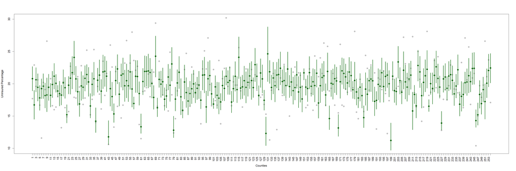

Standard Model (2022).

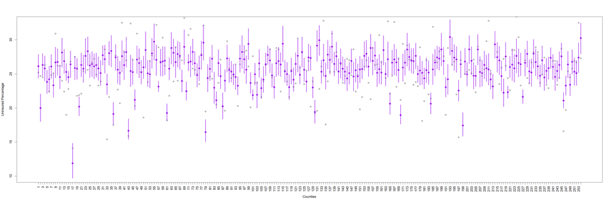

Standard Model (2012).

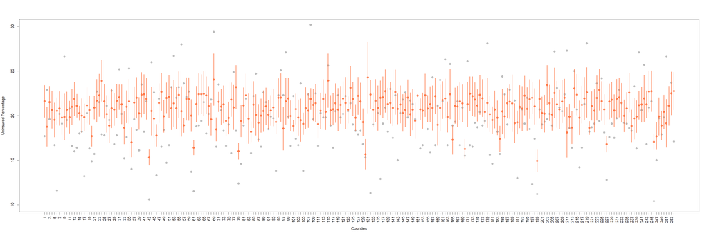

Global-Local Model (2022).

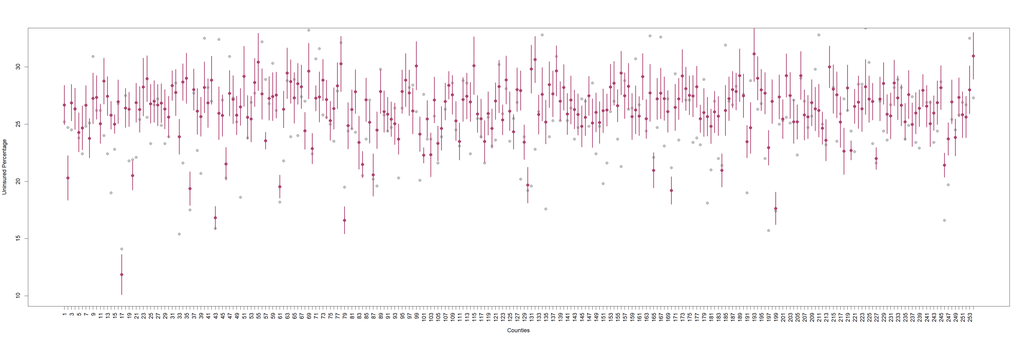

Global-Local Model (2012).